# index – Vitus Bering exploring the Data seas

Author

Affiliation

[Henrik Vitus Bering Laursen](https://github.com/Henkevitus)

[Seeking new opportunities](https://www.linkedin.com/in/henrikvitusberinglaursen/)

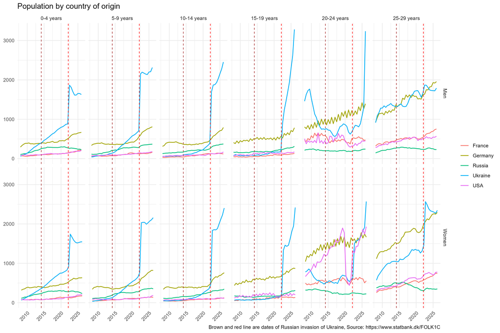

### Statbank API access and interesting observations

api

statbank

dst

descriptive statistics

war

I want to explore data from Statistics Denmark.

May 19, 2026

Henrik Vitus Bering Laursen

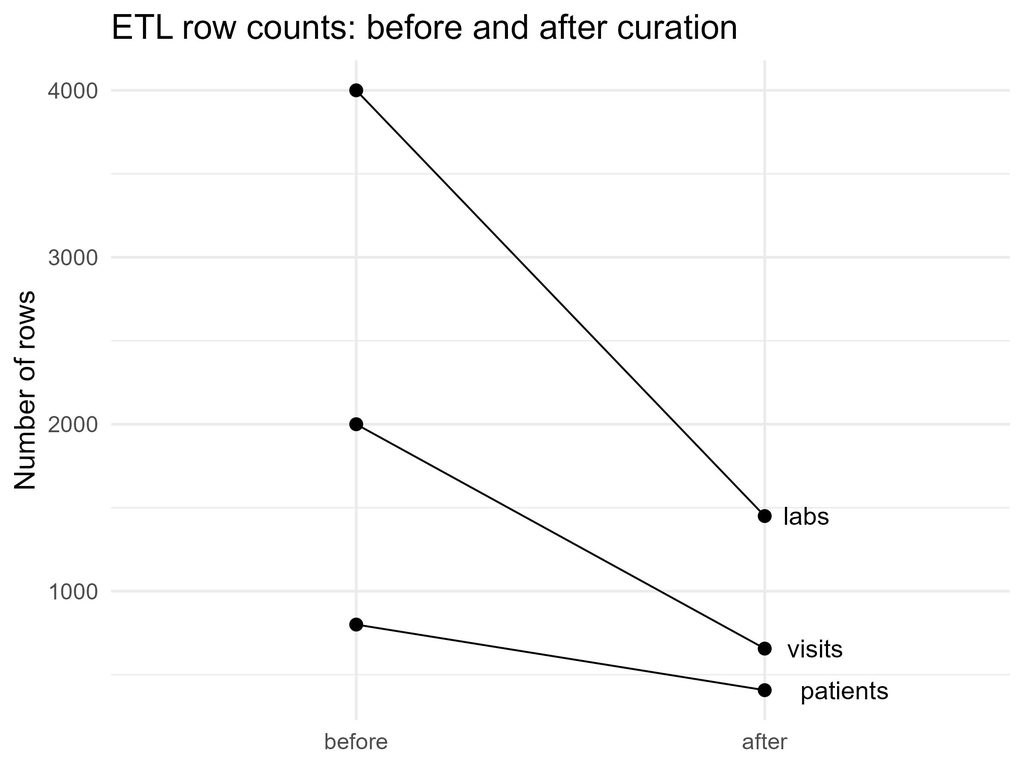

### ETL, and calling it

etl

analysis

functions

It’s been a while!

May 6, 2026

Henrik Vitus Bering Laursen

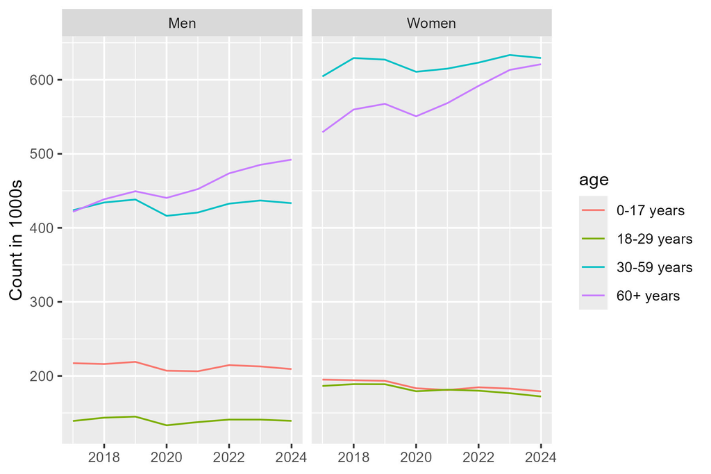

### R shiny

hospital usage

r shiny dashboard

I wanted to walk through how to use `R shiny` and put in some publicly available Danish statistics as the basis for a dashboard.

Sep 25, 2025

Henrik Vitus Bering Laursen

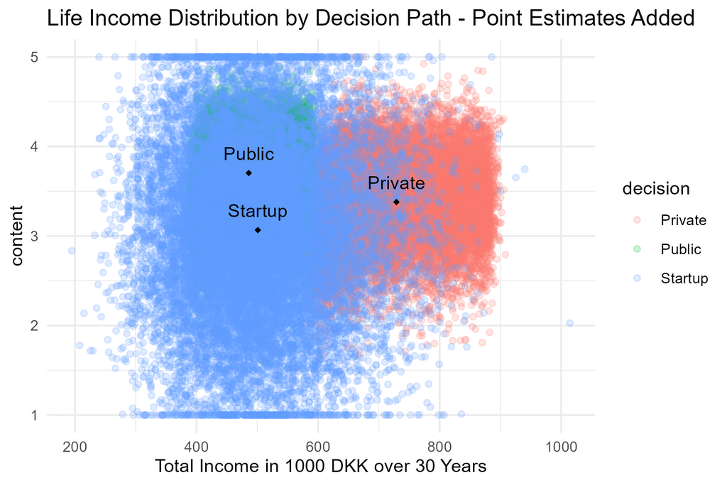

### Monte Carlo, Life paths, and AI

forecasting

monte carlo simulation

life path

randomness

Nassim Taleb

AI

Mentor mentee

This blogpost was concieved as a short look at monte carlo simulation, but turned into both musings on some health economic decision principles, and discussion of the…

Jul 10, 2025

Henrik Vitus Bering Laursen

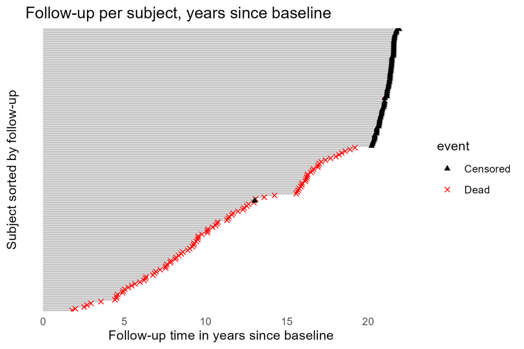

### Danish diabetes data

diabetes

data exploration

joins

survival analysis

I remember using the `Epi::steno2` data-sets when taking a short course on multistate survival analysis with the creator of the package, Bendix Carstensen.

Jun 17, 2025

Henrik Vitus Bering Laursen

### Moving on

announcement

I’m BACK!

May 31, 2025

Henrik Vitus Bering Laursen

### Got the PhD

announcement

Here with two things:

Jan 19, 2025

Henrik Vitus Bering Laursen

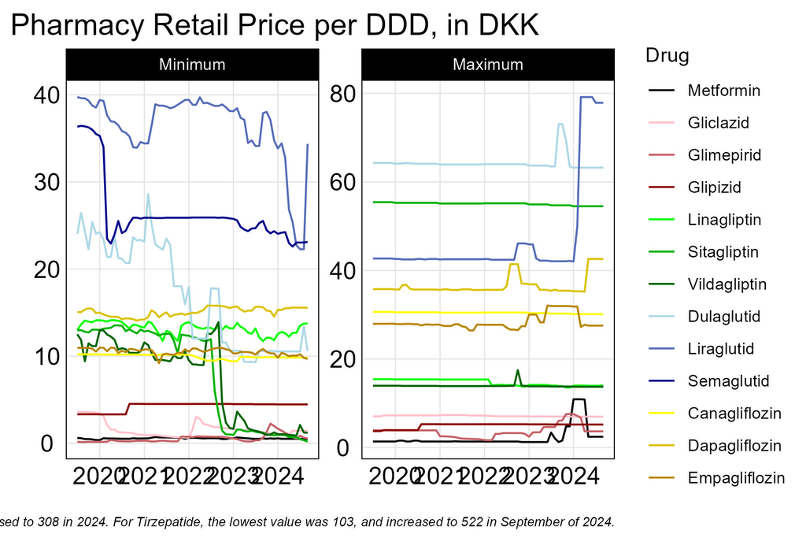

### Evolution in DDD use of Diabetes Drugs over time

code

analysis

exploration

cost

drugs

My two previous posts examined data available from medstat and were focused on those datasets and specifically the turnover of specific drug classes.

Sep 30, 2024

Henrik Vitus Bering Laursen

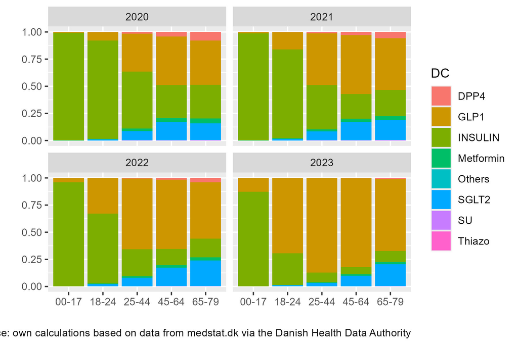

### Using R functions on medstat data

code

analysis

exploration

functions

cost

drugs

I want to follow up the previous post, and the promise of showing how to put it all in to a function.

Sep 20, 2024

Henrik Vitus Bering Laursen

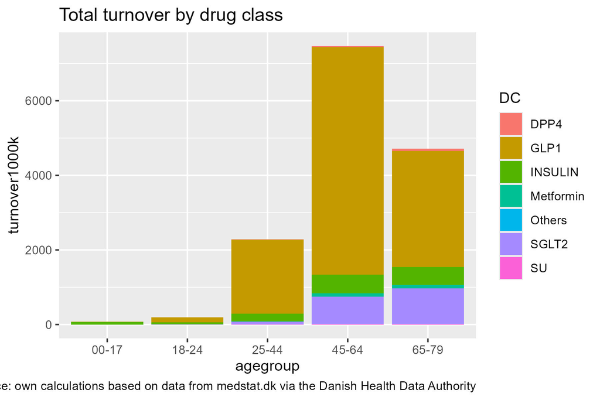

### Making sense of Medstat.dk data

code

analysis

exploration

cost

drugs

In this post, I’ll showcase how to work with publicly available drug prescription data from medstat.dk. This is a great way to practice data manipulation and analysis, using…

Sep 19, 2024

Henrik Vitus Bering Laursen